# Retail Forecasting

Prajwal Brijesh Ainapur

9/23/2018

# CRISP - DM for sales in the company

# Reading the Dataset

```
##         date      men    women    jewel mail page phone    print service
## 1 1989-01-01 11357.92 16578.93 10776.38 7978   73    34 22294.48      20
## 2 1989-02-01 10605.95 18236.13 10821.97 8290   88    29 27426.47      20
## 3 1989-03-01 16998.57 43393.55 22845.79 8029   65    24 27978.66      26
## 4 1989-04-01  6563.75 30908.49 11102.62 7752   85    20 28949.65      22
## 5 1989-05-01  6607.69 28701.58 16066.57 8685   74    17 22642.27      21
## 6 1989-06-01  9839.00 29647.57 11061.28 7847   87    30 27210.61      23
##   YEAR_ MONTH_    DATE_ Seasonal_Err_Men Seasonal_AdjSer_Men
## 1  1989      1 JAN 1989         0.919551           11932.955
## 2  1989      2 FEB 1989         0.846981           12550.903
## 3  1989      3 MAR 1989         1.496159           19971.321
## 4  1989      4 APR 1989         0.678450            7727.042
## 5  1989      5 MAY 1989         0.753748            7732.708
## 6  1989      6 JUN 1989         1.134113           11363.275
##   Seasonal_Factors_Men Seasonal_TrendCycle_Men
## 1             0.951811                12976.93
## 2             0.845035                14818.39
## 3             0.851149                13348.39
## 4             0.849452                11389.26
## 5             0.854512                10259.01
## 6             0.865860                10019.53
```

# Data Pre-Processing

Step 1: Checking for any Missing Data and Statistical Summary

```
## data
##
##  16  Variables      120  Observations
## ---------------------------------------------------------------------------
## date
##        n  missing distinct
##      120        0      120
##
## lowest : 1989-01-01 1989-02-01 1989-03-01 1989-04-01 1989-05-01
## highest: 1998-08-01 1998-09-01 1998-10-01 1998-11-01 1998-12-01
## ---------------------------------------------------------------------------
## men
##        n  missing distinct     Info     Mean      Gmd      .05      .10
##      120        0      120        1    16243     6819     8395    10039
##      .25      .50      .75      .90      .95
##    11750    15452    19094    24305    27875
##
## lowest :  3245.18  6563.75  6607.69  6766.94  8214.14
## highest: 30208.17 31090.05 34028.01 38236.59 38609.66
## ---------------------------------------------------------------------------
## women
##        n  missing distinct     Info     Mean      Gmd      .05      .10
##      120        0      120        1    40584    13526    21714    24420
##      .25      .50      .75      .90      .95
##    33010    39779    46877    54789    61311
##
## lowest : 16578.93 18103.06 18236.13 20078.40 20789.67
## highest: 65196.81 69112.81 73918.34 75818.17 80245.97
## ---------------------------------------------------------------------------
## jewel
##        n  missing distinct     Info     Mean      Gmd      .05      .10
##      120        0      120        1    16741     7036     9925    10988
##      .25      .50      .75      .90      .95
##    12077    14241    20311    26049    32893
##
## lowest :  5983.55  8641.83  8713.27  9595.20  9597.03
## highest: 34065.23 34645.89 34929.23 35893.86 38231.57
## ---------------------------------------------------------------------------
## mail
##        n  missing distinct     Info     Mean      Gmd      .05      .10
```

[output cut: 96 more lines]

```
## Proportion    0.083    0.083    0.083    0.083    0.083    0.083    0.083
##
## Value      0.950968 0.951811 1.109078 1.140925 1.794575
## Frequency        10       10       10       10       10
## Proportion    0.083    0.083    0.083    0.083    0.083
## ---------------------------------------------------------------------------
## Seasonal_TrendCycle_Men
##        n  missing distinct     Info     Mean      Gmd      .05      .10
##      120        0      120        1    16233     4235    11397    11945
##      .25      .50      .75      .90      .95
##    13101    15235    19417    21134    21619
##
## lowest : 10019.53 10259.01 10866.22 10895.33 11378.31
## highest: 22714.96 23524.17 24702.62 25270.89 26004.76
## ---------------------------------------------------------------------------
```

Histogram Plot for the sales of men’s clothing

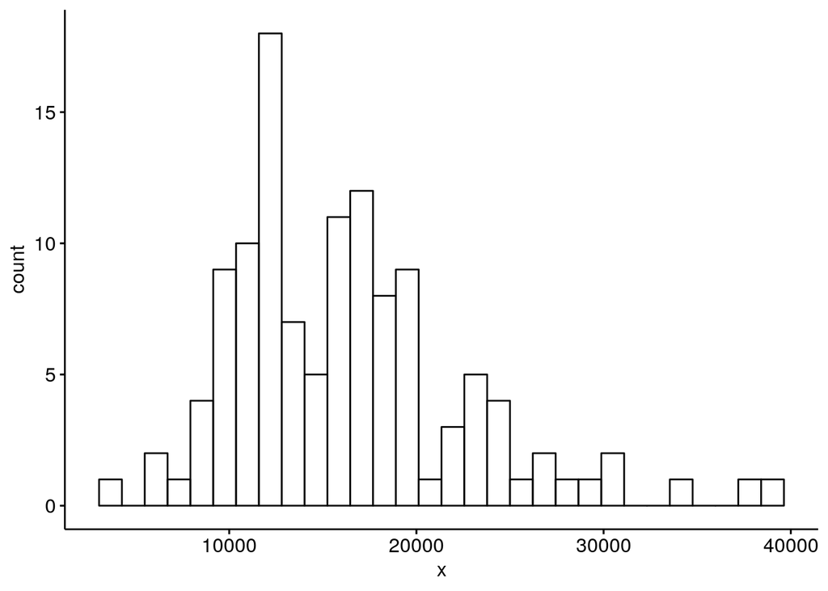

Histogram Plot for the sales of women’s clothing

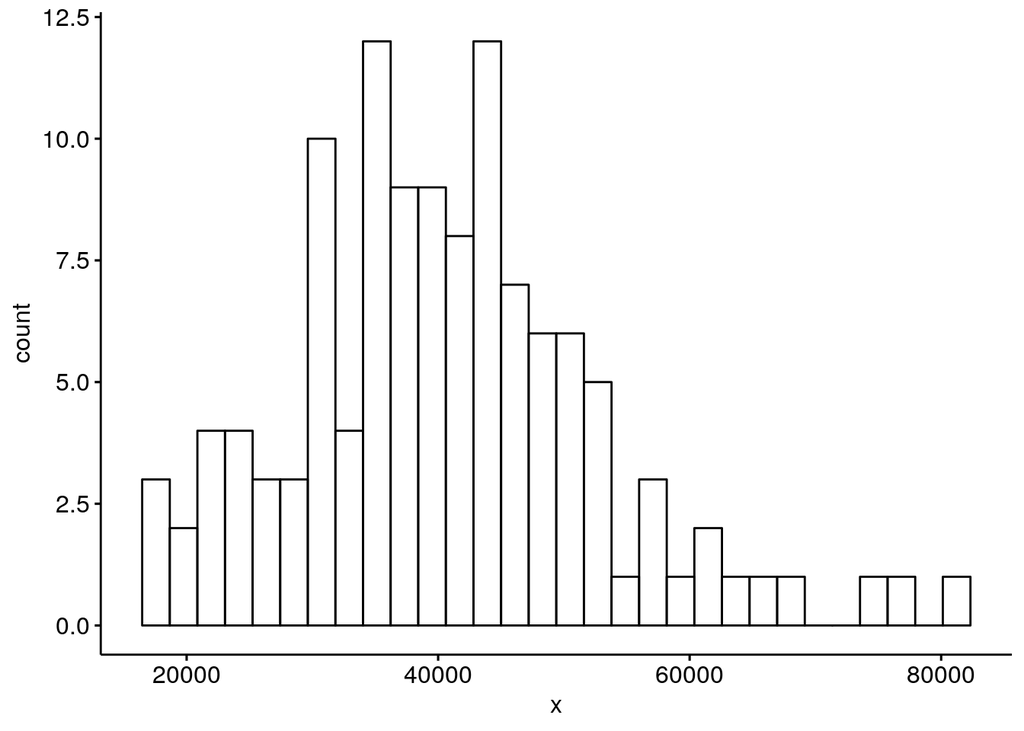

=> Testing for normality using Shapiro-Wilk Test

```
##
##  Shapiro-Wilk normality test
##
## data:  data$men
## W = 0.92988, p-value = 9.464e-06
```

```
##
##  Shapiro-Wilk normality test
##
## data:  data$women
## W = 0.97396, p-value = 0.01978
```

Result: 1: The p-value for both the sales data is not normally distributed. 2: Data Normalization is required.

ii -> Calculating the trend and removing it for men’s sales

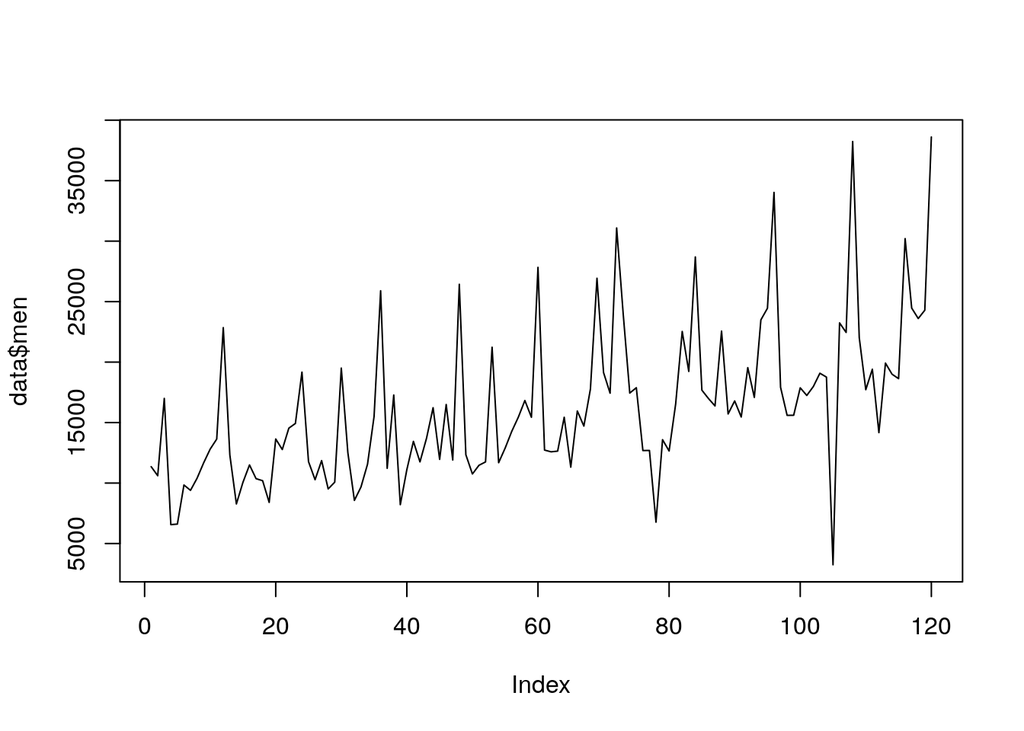

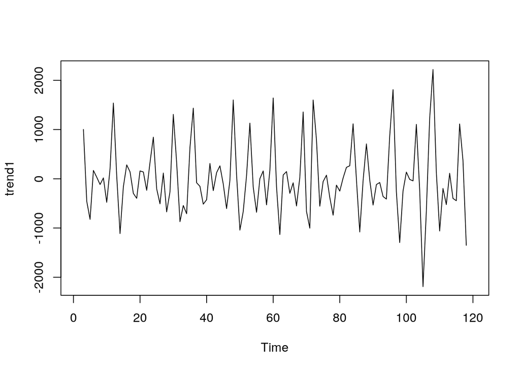

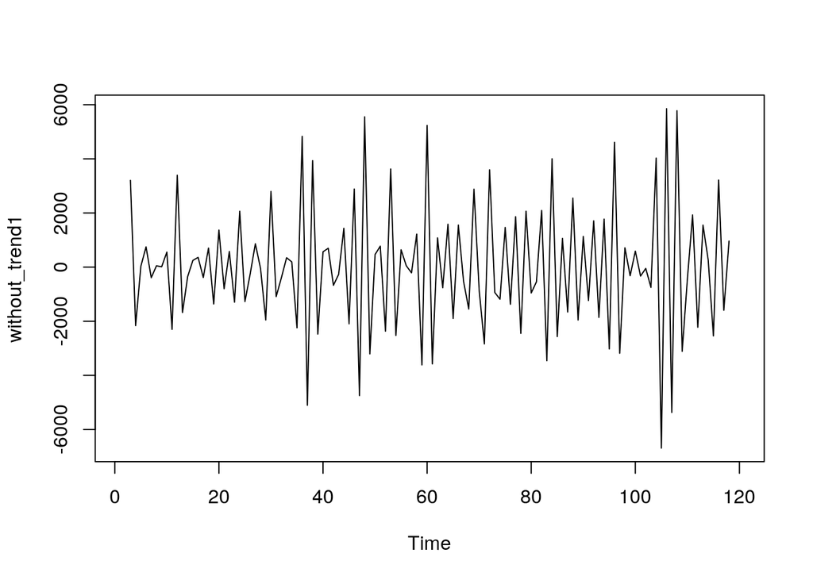

ii -> Normalizing the data using skewness reduction techniques

```
## Skewness of the original data of the women's sales is: 0.5876654
```

```
## SKewness of the normalized data for the women's sales is: -0.05918168
```

The skewness of the women’s sales data shows a positive skewness of 0.58 and thus is right skewed. Right skewed data can be reduced by cube root method and as a result of which the skewness was reduced by 10 times.

iii -> Z-Score Standardisation

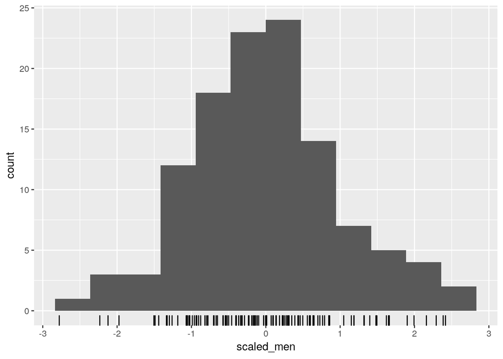

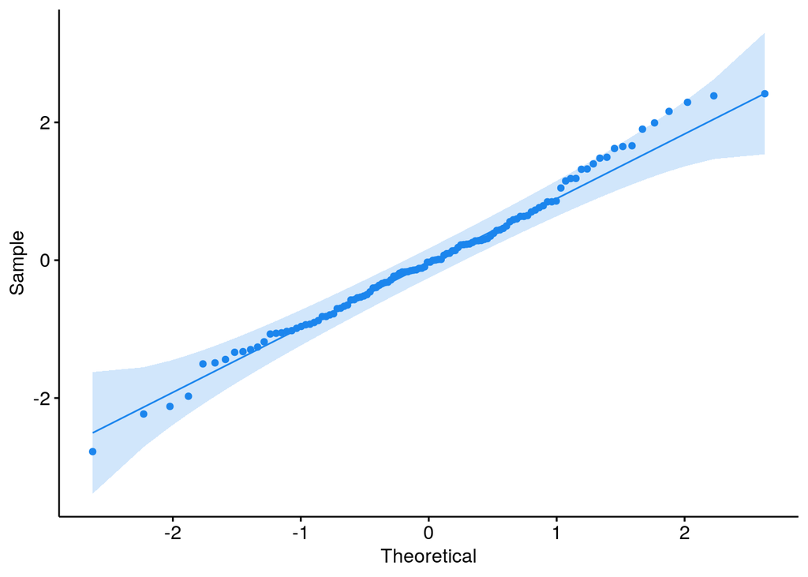

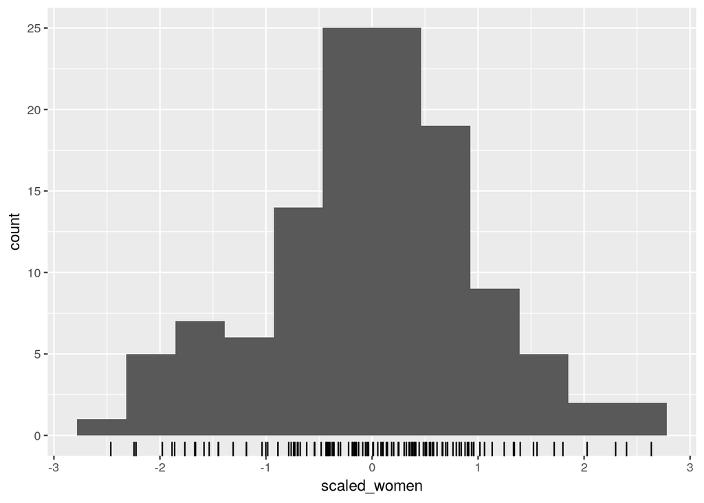

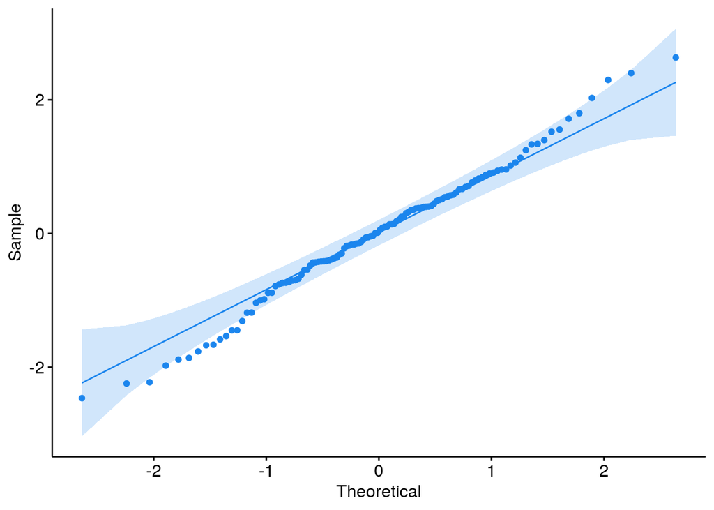

Result: The above plot shows that the points now lie closer to the line, after removing the seasonality.

# EDA

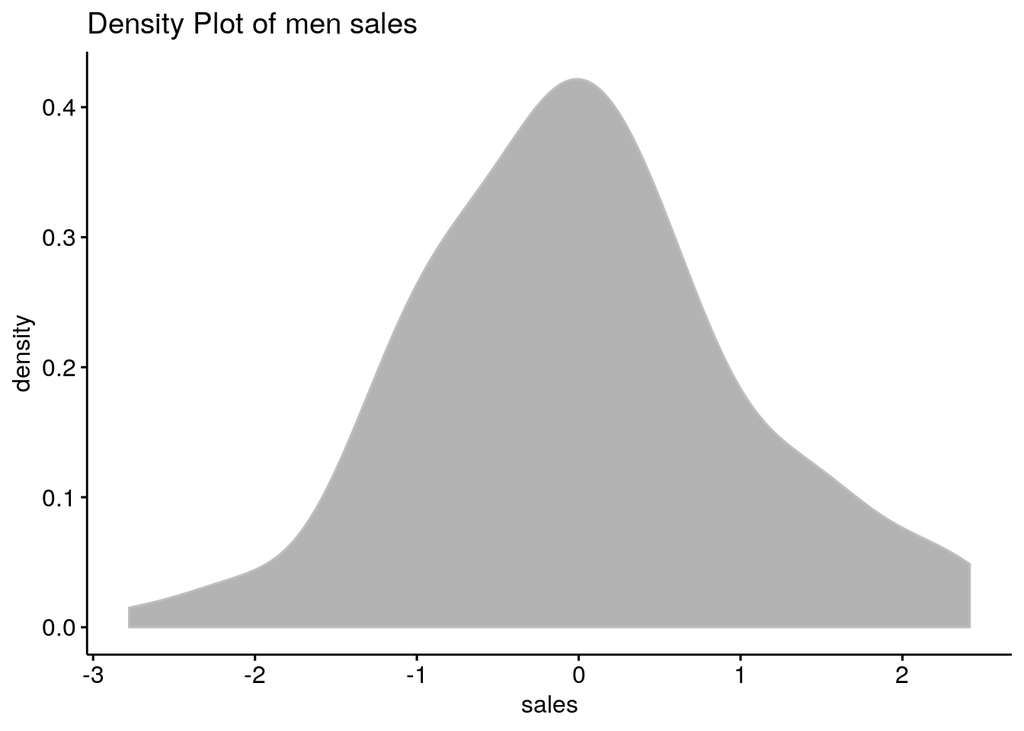

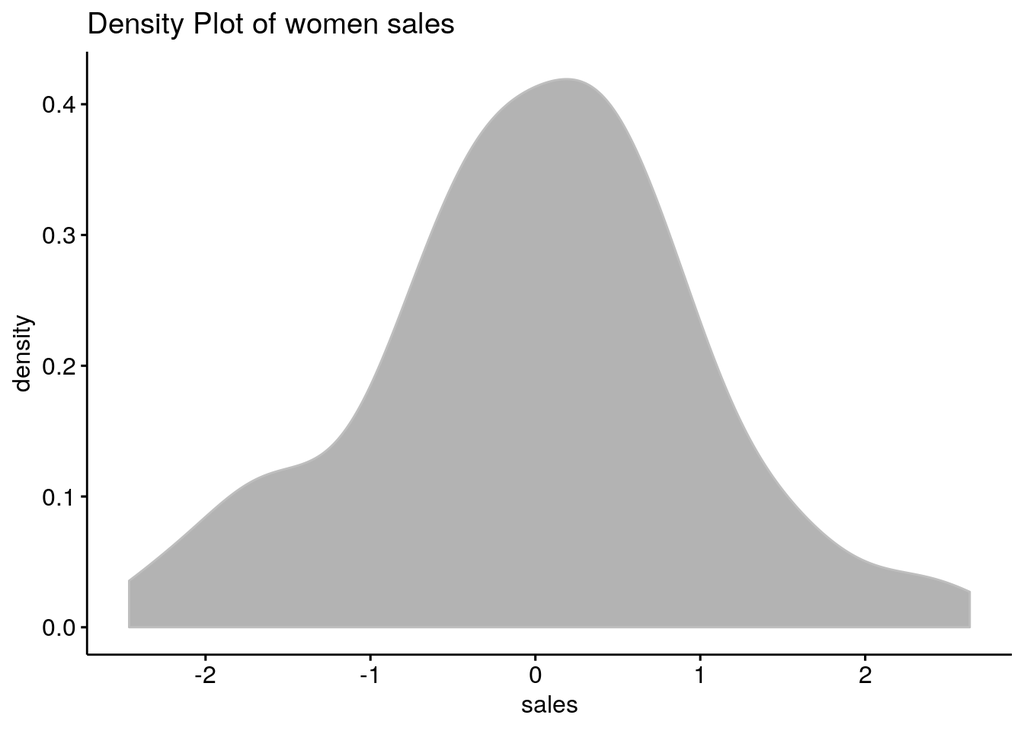

=> Testing for normality

```
##
##  Shapiro-Wilk normality test
##
## data:  scaled_men
## W = 0.98955, p-value = 0.5204
```

```
##
##  Shapiro-Wilk normality test
##
## data:  scaled_women
## W = 0.99092, p-value = 0.619
```

Result: The data has a considerably good p-value and thus cleares the test for normality

```
## Correlation coeffficient between the men's and women's sales is 0.4793316
```

[output not shown]